# Introduction to R & RStudio

05 July 2019

## What is R and RStudio?

- R `->` both the programming language and the software that interprets the scripts
- RStudio `->` a front end (interface) to R, which makes using R a lot nicer

## Why learn R?

- R doesn’t involve lots of pointing and clicking - easy to redo analysis if you collected more data
- R code is great for reproducibility - obtain same results from same dataset using same analysis
- R is extensible and interdisciplinary - ~14,000 packages to extend its capabilities, and statistical approaches from many scientific disciplines can be combined
- R works on data of all shapes and sizes - it is designed for data analysis
- R produces high-quality graphics - can adjust any aspect of your graph
- R has a large community - mailing lists and websites (Stack Overflow)
- R is open-source and cross-platform - Anyone can inspect the source code - less chance for mistakes

## Layout of RStudio

[figure not shown]

Credit: Jessica Ward, PhD Student, Newcastle University

## Create a new project

- It is good practice to keep a set of related data, analyses and text in single folder called the “working directory”
- You can easily share it with others without worrying about whether or not underlying scripts will still work
- Only ever use relative paths and not absolute paths

## Absolute vs relative paths

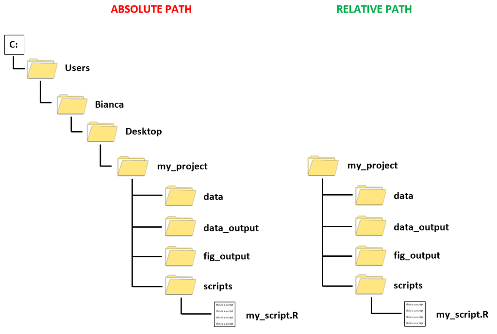

## Time for…

## Your working directory should look like this

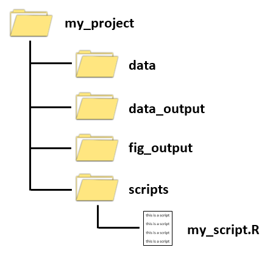

* Working directory = where R looks for files that you ask it to load, and where it will put any files that you ask it to save

## Interacting with R

- We write code/instructions = commands
- The computer executes/runs those commands
- Two ways to interact with R:
  - Type in the console and press Enter to execute -> forgotten when closed
  - Type in script editor and press Ctrl + Enter -> save code and workflow
- Prompt > is displayed when R is ready to accept commands
- Receives commands (typing, copy-pasting or sent from script editor) -> execute -> show results -> new prompt
- If R waits for more data -> will show a + prompt (continuation symbol), which means you haven’t finished entering a complete command
- Either enter the missing letter/value/symbol or click inside the console and press Esc

## Seeking help

- Where to ask for help:
  - Friendly colleagues
  - Stack Overflow: http://stackoverflow.com/questions/tagged/r
  - R-help mailing list: https://stat.ethz.ch/mailman/listinfo/r-help
    - Use correct vocabulary
    - Check for package-specific mailing lists
    - List of topic-specific mailing lists: http://www.r-project.org/mail.html
- Use built-in RStudio help interface (bottom-right panel)
- ?function()
- ??function()

## Time for…

## Structure of R expressions

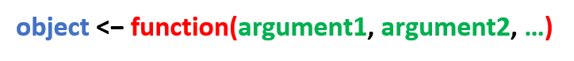

- object = can be any word you like, but avoid dots (and no spaces!)
  - also watch out for existing function names
- `<-` = assignment operator
- function = name of the function followed directly by ()
  - Example: `x <- round(3.14159)`
- arguments = specified within the () of the function, separated by commas
  - Example: `x <- round(3.14159, digits = 2)`

## Time for…

## Data structures vs Data types

- Data structures:
  - Vector
  - Matrix
  - Array
  - Data Frame
  - List
  - Factor
- Data types:
  - Numeric
  - Integer
  - Complex
  - Logical
  - Character

## Data structures

- Vector: one-dimensional array used to store collection data of the same mode.
- Matrix: two-dimensional array to store collections of data of the same mode.
- Array: similar to matrix, but can be multi-dimensional.
- Factor: vector of categorical variables designed to group the components.
- Data Frame: similar to matrices, but different columns can store different mode data.
- List: ordered collection of objects, where the elements can be of different types.

## Data types

[figure not shown]

Credit: Venkatesan Prabu .J (Wikitechy) https://www.wikitechy.com/tutorials/r-programming/r-datatypes-vectors

## Time for…

## Importing data

- Sometimes there are a few lines of metadata at the top of the file:
  - You can use `skip = n` to skip the first n lines.
  - Or use `comment = "#"` to drop all lines that start with `#`.
- The data might not have column names:
  - You can use `col_names = FALSE` to tell `read_csv()` not to treat the first row as headings, and instead label them sequentially from X1 to Xn.
  - Alternatively you can pass `col_names` a character vector which will be used as the column names
- Specify the value (or values) that are used to represent missing values in your file:
  - `read_csv("data.csv", na = ".")`

## Time for…

## Factors

```r
x <- factor(c("wallet", "gum", "lotion", "sanitizer", "lip-gloss"))
levels(x)
```

```
## [1] "gum"       "lip-gloss" "lotion"    "sanitizer" "wallet"
```

[figure not shown]

## Time for…

## Formatting dates

| Order of date elements | Parse function |
| --- | --- |
| year month day | ymd() |
| year day month | ydm() |
| month day year | mdy() |
| day month year | dmy() |
| hour minute | hm() |
| hour minute second | hms() |
| year month day hour minute second | ymd_hms() |

## Time for…

## Data manipulation using dplyr and tidyr

- dplyr package makes tabular data manipulation easier
- tidyr package enables you to convert between different data formats for plotting and analysis
- New functions/analyses are developed and made available via packages
- Packages = additional functions that let you do more stuff
- Install package once - install.packages()
- Load pacakage with every R session when you need it
- tidyverse = umbrella package that installs several packages

## Time for…

## Pipes

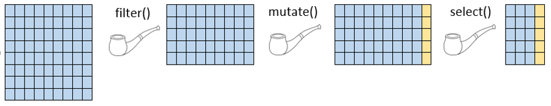

## Time for…

## Split-apply-combine analysis

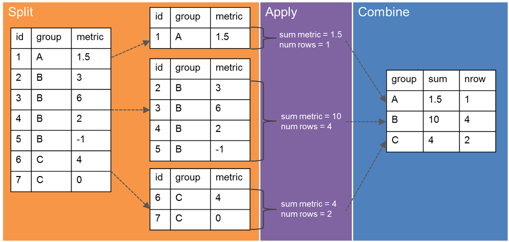

* It collapses each group into a single-row summary of that group

Credit: Ranae Dietzel & Andee Kaplan, https://agron590-isu.github.io/materials/week_08/dplyr/slides_dplyr.html

## Time for…

## Reshaping your data: spread

[figure not shown]

Credit: Data Carpentry, https://datacarpentry.org/R-ecology-lesson/

## Time for…

## Reshaping your data: gather

[figure not shown]

Credit: Data Carpentry, https://datacarpentry.org/R-ecology-lesson/

## Time for…

## Data visualization: building plots iteratively

`ggplot(data = <DATA>) + <GEOM_FUNCTION>(mapping = aes(<MAPPINGS>))`

- `<DATA>` = your dataframe containing the data you want to plot
- `<GEOM_FUNCTION>` = geometrical object that a plot uses to represent data, e.g. geom_line
- `<MAPPINGS>` = defines how variables in your dataset are mapped to visual properties [global mappings vs local mappings]

## Time for…

## Some other useful functions

```r
# Import data by browsing for file
my_data <- read.csv(file.choose(new = TRUE))

# Import Excel file (per sheet)
library(readxl)

read_excel("data/my_data.csv", sheet = "Sheet1")
```

## Some other useful functions

```r
# Update a package
tidyverse_update()

# Helper function to use within filter():
between(weight, 30, 50)

# Helper functions to use within select():
ends_with("xyz")
contains("cde")
select(df, col5, col6, everything())

# Create and keep only the new column:
transmute(df, new_column = old_column*2)

# Global substitutions (i.e. find and replace):
gsub(pattern, replacement, data)
```

## Some other useful functions

```r
# Remove an object from the environment
rm(object_name)

# Detach (i.e. "unload") a package
detach(tidyverse)

# Pick the top one (from arranged data)
dataframe %>%
  filter(!is.na(var1)) %>%
  arrange(var1, var2, var3) %>%
  slice(1)

dataframe %>%
  filter(!is.na(var1)) %>%
  arrange(var1, var2, var3) %>%
  top_n(1)
```

## Some other useful functions

```r
# Divide data into categories:
mutate(category = case_when(weight <= 100 ~ "small",
                            weight > 100 & weight < 200 ~ "medium",
                            weight > 200 ~ "large"))

# Rename specific column headers:
rename(df, new_name = old_name)

# Top 10 heaviest animals:
top_n(df, 10, weight)

# Separate (i.e. split) one column into multiple:
separate(column, into = c("col1", "col2"))

# Bind tables on columns or rows
cbind(df1, df2, ...)
rbind(df1, df2, ...)
```

## Some other useful functions

- Mutating joins: combine variables from two data.frames
  - inner_join(x, y, by = “key”) keeps all observations present in both x and y.
  - left_join(x, y, by = “key”) keeps all observations in x.
  - right_join(x, y, by = “key”) keeps all observations in y.
  - full_join(x, y, by = “key”) keeps all observations in x and y.
- Filtering joins: keep cases from the left-hand data.frame
  - semi_join(x, y) keeps all observations in x that have a match in y.
  - anti_join(x, y) drops all observations in x that have a match in y.
- Nesting joins: create a list column of data.frames
  - nest_join(x, y, by = “key”) keeps all rows and all columns from x and adds a list column of tibbles
- Set operations: compare values of every variable
  - intersect(x, y): return only observations in both x and y.
  - union(x, y): return unique observations in x and y.
  - setdiff(x, y): return observations in x that are not in y.

## IF statements

```r
if (condition) {
  # code executed when condition is TRUE
} else {
  # code executed when condition is FALSE
}


if (this) {
  # do this
} else if (that) {
  # do that
} else {
  # do something else
}
```

## IF statements

```r
temp <- 15

if (temp <= 0) {
  "freezing"
} else if (temp <= 10) {
  "cold"
} else if (temp <= 20) {
  "cool"
} else if (temp <= 30) {
  "warm"
} else {
  "hot"
}
```

## Writing your own function

- Functions allow you to automate common tasks instead of copy-and-pasting
- Writing a function has 3 main advantages over using copy-and-paste:
  - You can give a function an evocative name that makes your code easier to understand.
  - As requirements change, you only need to update code in one place, instead of many.
- You eliminate the chance of making incidental mistakes when you copy and paste (i.e. updating a variable name in one place, but not in another).

## Writing your own function

```r
function_name <- function(x) {
  y <- read.csv(x)

  y %>%
    count(variable)
}

# Example

get_species <- function(x) {
  y <- read.csv(x)

  y %>%
    count(species)
}
```

## Useful shortcuts

- Ctrl + Shift + N = New script
- Alt + “-” = Assignment operator `<-`
- Ctrl + Enter = Run selected command(s)
- Ctrl + Shift + S = Run the whole script
- Ctrl + Shift + R = Create script headers
- Alt + Shift + K = Keyboard shortcut quick reference
- F1 (when function is highlighted in pop-up tooltip) = activates help window
- Ctrl + Shift + M = Insert pipe character %>%

## Summary

- RStudio projects give you a solid workflow that will serve you well in the future:
  - Create an RStudio project for each data analysis project.
  - Create a file structure that is logical and reusable - helps to automate future work.
  - Keep raw data files there.
  - Keep scripts there.
  - Save your outputs (plots and cleaned data) there.
  - Only ever use relative paths, not absolute paths.

## Summary

[figure not shown]